# ML_Lab1

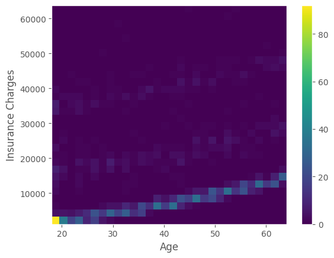

```python
#Age vs. Insurance Charges
#focus only on age, see how increase in age affects insurance
plt.hist2d(x=df.age, y=df.charges, bins=30)
plt.colorbar()
plt.xlabel("Age")
plt.ylabel("Insurance Charges")
plt.show()
#Shows a steadily increasing medical insurance charge as age increases
```

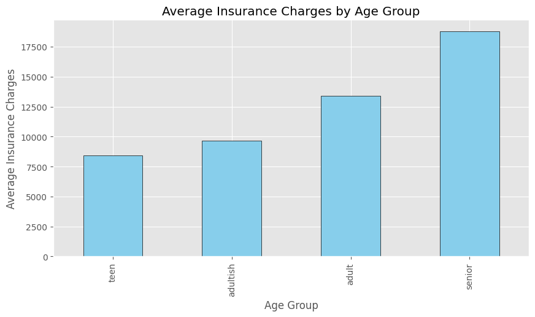

```python
#Age Group vs. Insurance Charges
plt.style.use('ggplot')

#average insurance charges for each age group
age_group_charges = df.groupby('age_range', observed=False)['charges'].mean()

#bar plot
plt.figure(figsize=(10,5))
age_group_charges.plot(kind='bar', color='skyblue', edgecolor='black')

plt.xlabel('Age Group')
plt.ylabel('Average Insurance Charges')
plt.title('Average Insurance Charges by Age Group')

plt.show()
```

**Conclusion:** These 2 plots confirm that the older you are, the more expensive medical insurance charges are. The second plot shows in more detail that charges grow significantly between adultish (19-25) and adult (25-55). Furthermore, they spike even more between the ages of adult(25-55) and senior (55+).

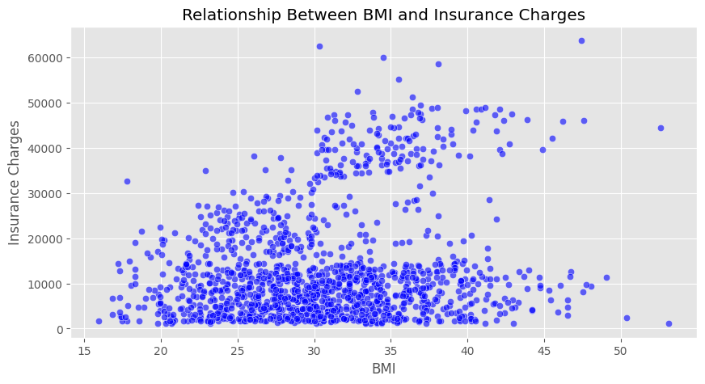

```python
#BMI vs Insurance Charges
#Coding help from source:  chatgpt.com
import seaborn as sns

plt.figure(figsize=(10, 5))
sns.scatterplot(x=df['bmi'], y=df['charges'], alpha=0.6, color='blue')

plt.xlabel('BMI')
plt.ylabel('Insurance Charges')
plt.title('Relationship Between BMI and Insurance Charges')

plt.show()
```

**Conclusion:** We see a generally upward trend, meaning that as BMI increases, typically insurance charges also increase. However, we also see that there are many points where people have similar BMI, but very differing medical insurance costs. To explore this further, lets categorize this into smokers and non-smokers.

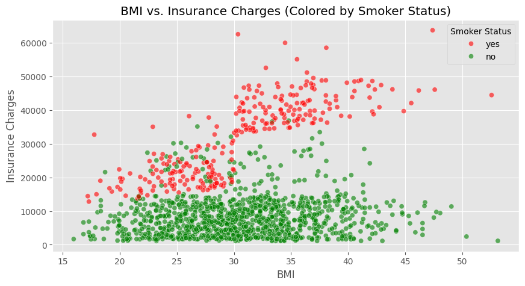

```python
#BMI & Smoker Status vs Insurance Charges
#Coding help from source:  chatgpt.com
plt.figure(figsize=(10, 5))
sns.scatterplot(x=df['bmi'], y=df['charges'], hue=df['smoker'], alpha=0.6, palette={'yes':'red', 'no':'green'})

plt.xlabel('BMI')
plt.ylabel('Insurance Charges')
plt.title('BMI vs. Insurance Charges (Colored by Smoker Status)')

plt.legend(title="Smoker Status")
plt.show()
```

**Conclusion:** Wow! This very definitivley shows that smoking increases charges, even when some people may have a higher BMI. This graph was very telling to me, it shows that regardless of BMI smoking has the greatest impact on health and therefore insurance charges.

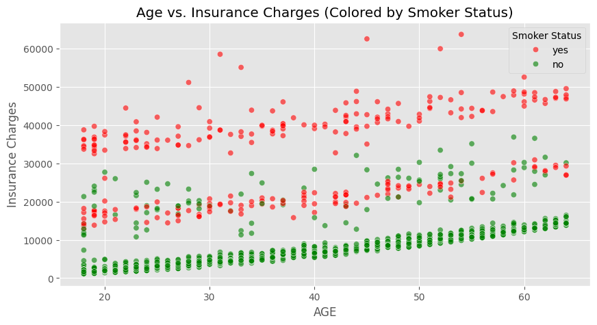

```python
#Age & Smoker Status vs Insurance Charges
#Coding help from source:  chatgpt.com
#Looking at the previous graph made me curious to see the same graph, but looking at age instead of BMI

plt.figure(figsize=(10, 5))
sns.scatterplot(x=df['age'], y=df['charges'], hue=df['smoker'], alpha=0.6, palette={'yes':'red', 'no':'green'})

plt.xlabel('AGE')
plt.ylabel('Insurance Charges')
plt.title('Age vs. Insurance Charges (Colored by Smoker Status)')

plt.legend(title="Smoker Status")
plt.show()
```

**Conclusion:** We see that theres a steady upwards trend for both non-smokers and smokers, confirming the idea that as age increases, typically so do medical charges. However, we also see here that charges are significantly higher for people who smoke, even compared to people who are the same age as them. For example, we see that between ages 40-50, the average medical insurance is about 10000 for non smokers, whereas for smokers the average charge looks to be around 40000. While there are some outliers, it's clear the trend is that charges are much higher for smokers regardless of age.

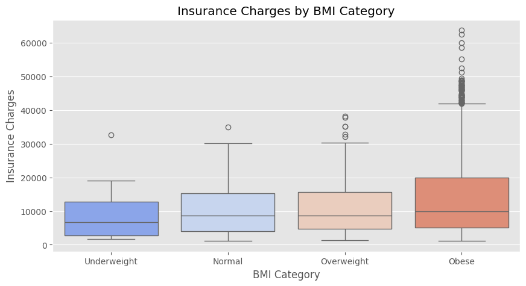

```python
#BMI Category vs Insurance Charges
#Coding help from source:  chatgpt.com

bmi_bins = [0, 18.5, 24.9, 29.9, 100]
bmi_labels = ['Underweight', 'Normal', 'Overweight', 'Obese']

df['bmi_category'] = pd.cut(df['bmi'], bins=bmi_bins, labels=bmi_labels)

plt.figure(figsize=(10, 5))
sns.boxplot(x=df['bmi_category'], y=df['charges'], hue=df['bmi_category'], palette='coolwarm', legend=False)

plt.xlabel('BMI Category')
plt.ylabel('Insurance Charges')
plt.title('Insurance Charges by BMI Category')

plt.show()
```

```python
#going to create a new dataset that contains all the same data, but classifies people as risk or no risk
df_risk = df.copy()   #make new dataset from copying the other one, add columns to this one
```

```python
#coding help from chatgpt.com
#classifying ppl as risk if they meet at least 2 criteria

df_risk['risk_level'] = np.where(
    ((df_risk['age'] > 60) & (df_risk['bmi'] > 40)) |  # very high age & BMI together = risk
    ((df_risk['smoker'] == 'yes') & (df_risk['age'] > 50)) |  # older smokers = risk
    ((df_risk['smoker'] == 'yes') & (df_risk['bmi'] > 40)),  # smokers who are severely obese = Risk
    'Risk', 'No Risk'
)

df_risk['risk_level'].value_counts()
```

| risk_level | count |
| --- | --- |
| No Risk | 1255 |
| Risk | 83 |

**dtype:** int64

Now that we have this classificaiton, lets look at some graphs and see who may be classified as "risk".

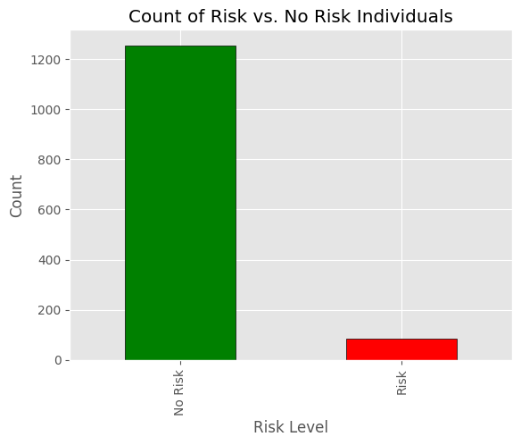

```python
plt.style.use('ggplot')

df_risk['risk_level'].value_counts().plot(kind='bar', color=['green', 'red'], edgecolor='black')

plt.xlabel('Risk Level')
plt.ylabel('Count')
plt.title('Count of Risk vs. No Risk Individuals')

plt.show()
```

We see most people are not classified as a risk. This is a pretty strict criteria to be classified as risk, so it would be important for medical insurance companies to double-check before accepting those labeled "risk" as a client. Lets double check our classification criteria to see if those labeled "risk" tend to have higher insurance charges (Which based off of our previous graphs, they should).

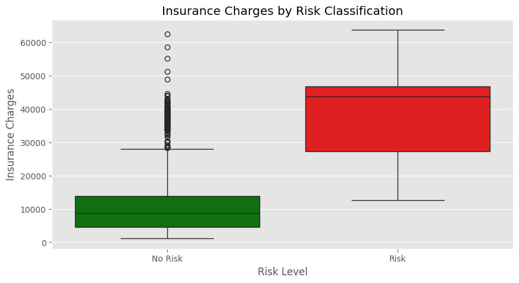

```python
plt.figure(figsize=(10,5))
sns.boxplot(x=df_risk['risk_level'], y=df_risk['charges'], hue=df_risk['risk_level'],
            palette={'No Risk':'green', 'Risk':'red'}, legend=False)

plt.xlabel('Risk Level')
plt.ylabel('Insurance Charges')
plt.title('Insurance Charges by Risk Classification')

plt.show()
```

This graph shows us that those labeled "risk" do indeed have higher insurance charges on average. This means our classification criteria is adequate for now, though it could always be made better through further research/analysis.

```python
from google.colab import drive
drive.mount('/content/drive')
```

```python
!jupyter nbconvert --to html "/content/drive/My Drive/Colab Notebooks/ML/Lab 1/ML_Lab1.ipynb"
```

```
[NbConvertApp] Converting notebook /content/drive/My Drive/Colab Notebooks/ML/Lab 1/ML_Lab1.ipynb to html
[NbConvertApp] WARNING | Alternative text is missing on 15 image(s).
[NbConvertApp] Writing 1370402 bytes to /content/drive/My Drive/Colab Notebooks/ML/Lab 1/ML_Lab1.html
```

```python
from google.colab import files
files.download("/content/drive/My Drive/Colab Notebooks/ML/Lab 1/ML_Lab1.html")
```